# Part2 : Quali-Quali

Guillaume

07/06/2022

#Representation of sensory attributes and bivariate analysis ## data importation, cleaning and selection

```r
library(FactoMineR)
library(SensoMineR)

#import
GMO <- read.csv("data/gmo.csv", sep=';')
GMO<-GMO[-136,]
#transform into factor
for (i in 1:21)
{
    GMO[, i] <- as.factor(GMO[, i])
}

#summary
summary(GMO)
```

```
##           Implicated         Position.Culture          Position.Al.H
##  A little      :31   Favourable      :45      Favourable      :37
##  A lot         :36   Somewhat Against:54      Somewhat Against:47
##  Certain extent:53   Totally opposed :33      Totally opposed :50
##  Not at all    :15   Very Favourable : 3      Very Favourable : 1
##
##
##
##           Position.Al.A Protest   Media.Passive Info.Active
##  Favourable      :44    No :122   No :78        No :82
##  Somewhat Against:39    Yes: 13   Yes:57        Yes:53
##  Totally opposed :44
##  Very Favourable : 8
##
##
##
##  Phytosanitary.products Hunger   Animal.feed Future.Progress Danger   Threat
##  No :56                 No :67   No :93      No :54          No :39   No :48
##  Yes:79                 Yes:68   Yes:42      Yes:81          Yes:96   Yes:87
##
##
##
##
##
##  Finan.risk Useless.practice Grandparents Sex          Age
##  No :67     No :123          No :49       F:71   [26; 40]:24
##  Yes:68     Yes: 12          Yes:86       H:64   [41; 60]:24
##                                                  < 25    :73
##                                                  > 60    :14
##
##
##
##               Profession Relation     Political.Party
##  Student           :69   No :79   Extreme left: 9
##  Senior Management :17   Yes:56   Greens      : 7
##  Retired           :14            Left        :47
##  Civil Servant     : 9            Liberal     :32
##  Other             : 9            Right       :40
##  Technician        : 6
##  (Other)           :11
```

```r
#selection variable Political.Party and Position.Al.A
GMO.Al.A <- GMO[,c( "Political.Party","Position.Al.A")]

#or tidyverse version :
library(dplyr)
GMO.Al.A <- GMO %>% select(c( Political.Party,Position.Al.A,))
```

## Bivariate analysis

We want to visualize both variables simultaneously. A barchat is appropriate to represent categories of one variable, but here it can also be useful to represent the cross-categories of the two variables.

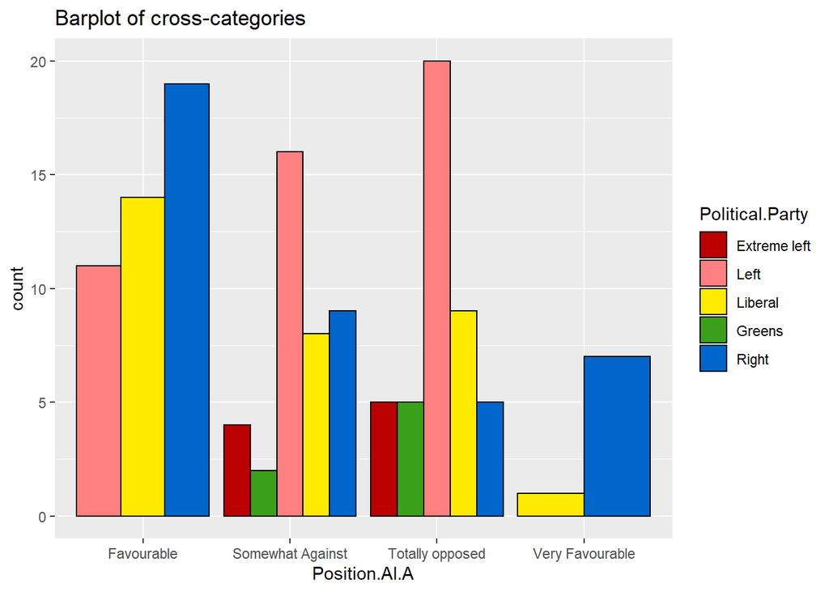

```r
library(ggplot2)

ggplot(GMO.Al.A, aes(Position.Al.A, ..count..)) + geom_bar(aes(fill = Political.Party), color="black", position = "dodge") + ggtitle("Barplot of cross-categories") +
  scale_fill_manual(values=c("Extreme left"="#bb0000","Left"="#FF8080","Liberal"="#ffeb00","Greens"="#3BA019","Right"="#0066cc"))
```

```r
## ..count.. : stat transformation of the original data set
```

#Concept of independance

## Sample data

To introduce this concept of independence, we remake the first part, but considering samples data. That means, we take keep a fixed column of our 2 variables dataframe, and we arranged randomly the second variable.

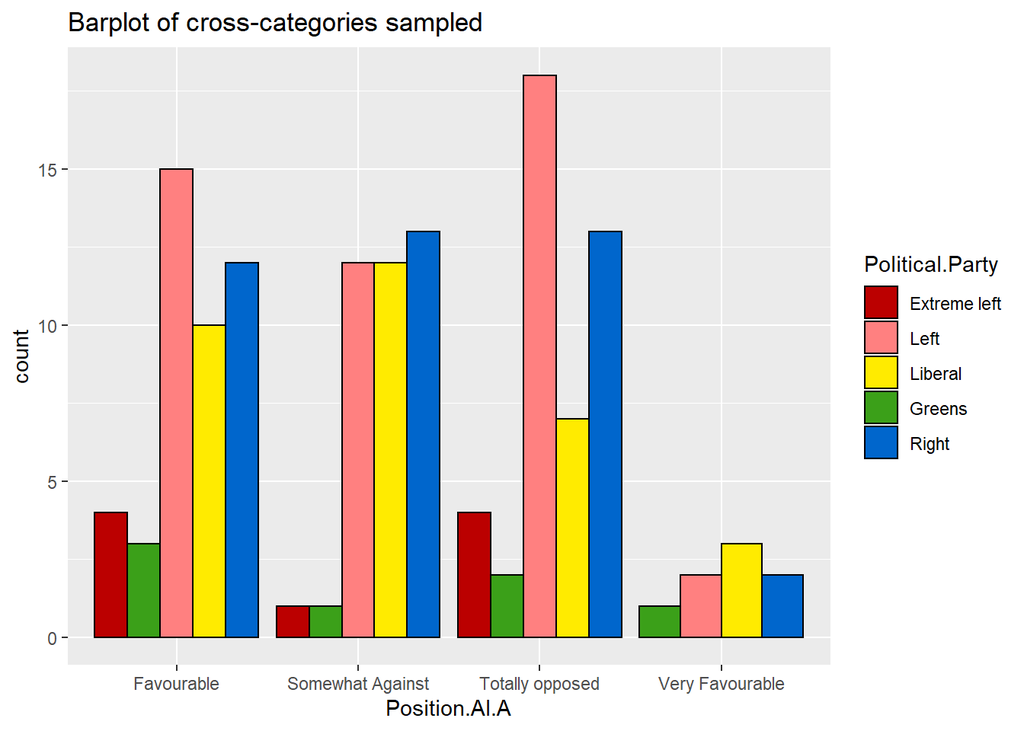

```r
set.seed(7)
ind.sample <- sample(1:135)
GMO.Al.A.Sample <- data.frame("Position.Al.A"=GMO.Al.A$Position.Al.A[ind.sample],'Political.Party'=GMO.Al.A$Political.Party)

#visualization
ggplot(GMO.Al.A.Sample, aes(Position.Al.A, ..count..)) + geom_bar(aes(fill = Political.Party), color="black", position = "dodge") + ggtitle("Barplot of cross-categories sampled") +
  scale_fill_manual(values=c("Extreme left"="#bb0000","Left"="#FF8080","Liberal"="#ffeb00","Greens"="#3BA019","Right"="#0066cc"))
```

## probability side

Study a link between two variables comes to position data to a referent situation, the absence of linkage. In term of probability, saying that two events A and B are independent comes to say :
$$\mathcal{P}(A\cap B)=\mathcal{P}(A)\cdot\mathcal{P}(B)$$
Hence, two qualitative variables are independent when we have the relation : $f_{ij}=f_{i\cdot}\cdot f_{\cdot j}$ The mutual probability only depends of marginal numbers.

## Referent situation

First, we construct the table of reference, **ie :** a table with the product
$$f_{i\cdot}\cdot f_{\cdot j}$$
in each cells. We have $f_{\cdot j}=\dfrac{1}{n}\sum\limits_{j\in\mathcal{J}}n_{ij}$ and $f_{i\cdot}=\dfrac{1}{n}\sum\limits_{i\in\mathcal{I}}n_{ij}$

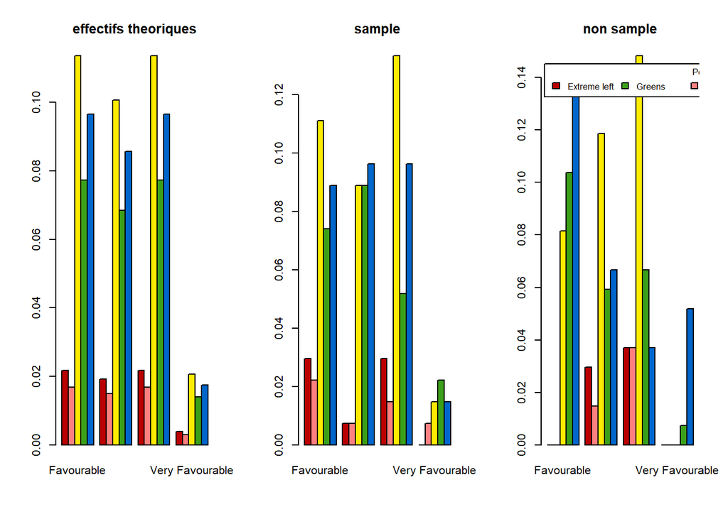

```r
#We start by adding margins to have row and column profiles
GMO_table <- as.data.frame.matrix(table(GMO.Al.A))
fi <- apply(GMO_table, 1, sum)/sum(GMO_table)
fj <- apply(GMO_table, 2, sum)/sum(GMO_table)
GMO_theo <- matrix(nrow=5,ncol=4)
for(i in 1:5){
for(j in 1:4) GMO_theo[i, j] <- (fi[i]*fj[j])
}
rownames(GMO_theo) <- rownames(GMO_table)
colnames(GMO_theo) <- colnames(GMO_table)

#barplot
par(mfrow=c(1,3))
barplot((as.table(as.matrix(GMO_theo))), beside = TRUE, main="effectifs theoriques", col=c("#bb0000","#FF8080","#ffeb00","#3BA019","#0066cc"))
barplot(t(table(GMO.Al.A.Sample))/135, beside = TRUE, main="sample",col=c("#bb0000","#FF8080","#ffeb00","#3BA019","#0066cc"))
barplot((table(GMO.Al.A)/135), beside = TRUE,main="non sample", col=c("#bb0000","#FF8080","#ffeb00","#3BA019","#0066cc"))
legend("topleft", inset=.02, title="Political Party", c("Extreme left","Greens","Left",'Liberal','Right'), horiz=TRUE, cex=0.8, fill=c("#bb0000","#3BA019","#FF8080","#ffeb00","#0066cc"))
```

We have our referent situation on the left, where variables are perfectly independant. The sample data is very closed to the it, but the original one seems to be deviate. We can try to make first hypothesis concerning a test on independence.

ggplot version :

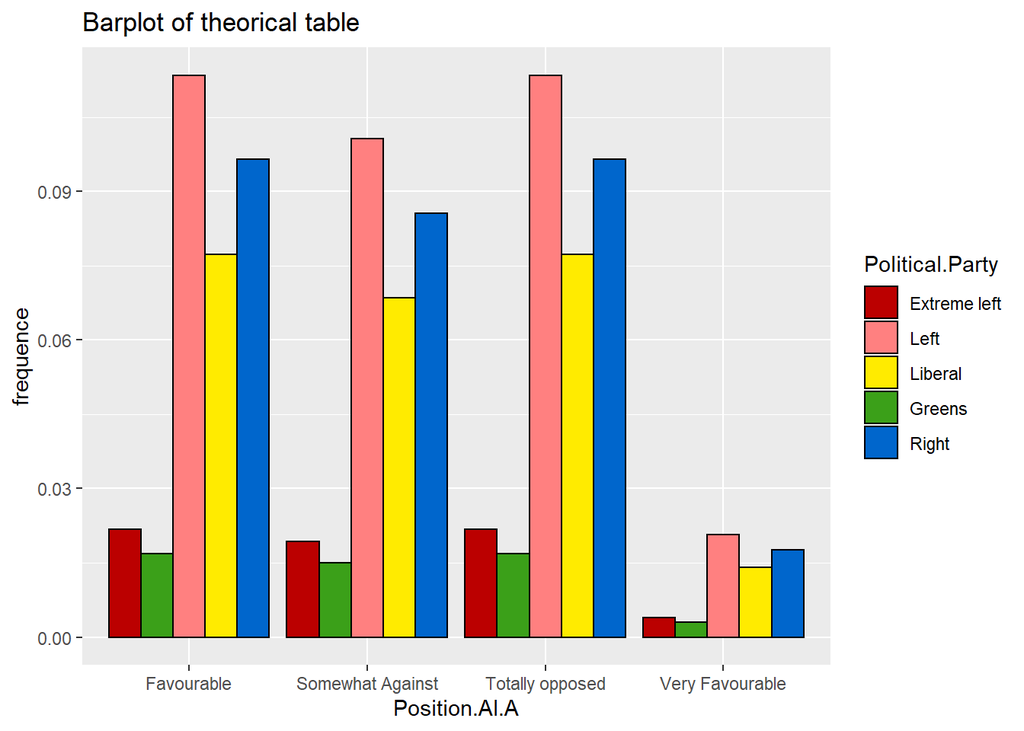

```r
library(tidyr)
df_theo <- as.data.frame.matrix(GMO_theo)
library(tibble)
df <- rownames_to_column(df_theo, "Political.Party")

df <- df %>% pivot_longer(!Political.Party, names_to="Position.Al.A", values_to = "frequence")
ggplot(df, aes(y=frequence,x=Position.Al.A, fill=Political.Party))+
         geom_col( position = "dodge", color="black")+ggtitle("Barplot of theorical table")+
  scale_fill_manual(values=c("Extreme left"="#bb0000","Left"="#FF8080","Liberal"="#ffeb00","Greens"="#3BA019","Right"="#0066cc"))
```

#Deviation to the independance

Now that we have our referent situation, we need to define a deviation to the independence for each pairs of categories. With the hypothesis of independence, we have the relation $f_{ij}=f_{i\cdot}\cdot f_{\cdot j}$ **ie :** $\dfrac{f_{ij}}{f_{i\cdot}\cdot f_{\cdot j}}-1=0$

```r
fi <- apply(GMO_table, 1, sum)/sum(GMO_table)
fj <- apply(GMO_table, 2, sum)/sum(GMO_table)
GMO_deviation <- matrix(nrow=5, ncol=4)
for(i in 1:5){
for(j in 1:4) GMO_deviation[i, j] <- (GMO_table[i, j]/sum(GMO_table)/((fi[i]*fj[j])))-1
}
rownames(GMO_deviation) <- rownames(GMO_table)
colnames(GMO_deviation) <- colnames(GMO_table)
```

These multivariate profiles (as vectors of $R^{J}$ and $R^{I}$) can be directly interpreted in terms of difference from the independence model.

The distance between i and i’ in terms of difference from the independence model lead to the comparison of the profile of i’ and the profile of i’, category by category. The name of the distance between two row profiles is called the Chi-square distance :
$$d^2(i,i') = d_{\chi^2}^2(i,i') = \sum\limits_{j\in\mathcal{J}}\dfrac{n}{n_{\cdot j}}(\dfrac{n_{ij}}{n_{i\cdot}}-\dfrac{n_{i'j}}{n_{i'\cdot}})^2$$

Calculate the distance matrix between row-profiles *ie* the political party.

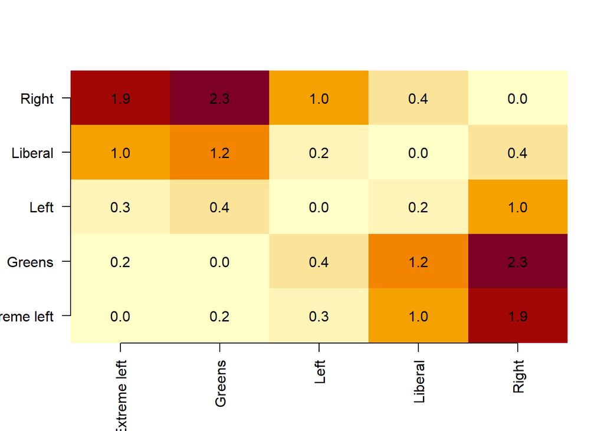

```r
ni <- apply(GMO_table,1, sum)#row sum
nj <- apply(GMO_table,2, sum)#col sum
n <- as.numeric(sum(ni))
GMO_chi2_row <- matrix(nrow=5, ncol=5)
for(i in 1:5){
for(j in 1:5){GMO_chi2_row[i, j] <- sum((n/nj)*((GMO_table[i,]/ni[i]) - (GMO_table[j,]/ni[j]))^2)}
}
rownames(GMO_chi2_row) <- rownames(GMO_table)
colnames(GMO_chi2_row) <- rownames(GMO_table)

dim <- ncol(GMO_chi2_row)
image(1:dim, 1:dim,GMO_chi2_row, axes=F, xlab="", ylab="")
axis(1, 1:dim, row.names(GMO_chi2_row), cex.axis=1, las=3)
axis(2, 1:dim, row.names(GMO_chi2_row), cex.axis=1, las=1)
text(expand.grid(1:dim, 1:dim), sprintf("%0.1f", GMO_chi2_row), cex=1)
```

The chi2 statistic is calculated with the `chisq.test` function. It also gives you the results of the test where the null hypothesis is the independence between the variables based on the statistic. If the statistic is too large, we will reject the hypothesis of independence and reciprocally.

```r
res.chi2.gmo <- chisq.test(GMO_table)
res.chi2.sample <- chisq.test(table(GMO.Al.A.Sample))
res.chi2.gmo$residuals
```

```
##              Favourable Somewhat Against Totally opposed Very Favourable
## Extreme left  -1.712698       0.86824314       1.2066734      -0.7302967
## Greens        -1.510457      -0.01562691       1.7997982      -0.6440612
## Left          -1.103383       0.65735449       1.1961205      -1.6688874
## Liberal        1.105551      -0.40929374      -0.4426792      -0.6508764
## Right          1.651478      -0.75177852      -2.2259045       3.0070327
```

#Inertia With a distance and a system of masses, we can now focus on the very important concept of inertia. By definition, as evoked in our introduction, the inertia of our Political party is obtained by the following calculation :
$$\mathcal{I}(N_{I}) = \sum\limits_{i\in\mathcal{I}} f_{i\cdot}\cdot d^2(i,\mathcal{O})$$
where $\mathcal{I}(N_{I})$ is the inertia of the system of rows, $N_{I}$ denotes the scatter plot of the rows in the $R^{J}$ space, and $\mathcal{O}$ denotes the center of gravity of $N_{I}$ .

#CA

```r
res.CA <- CA(GMO_table)
```

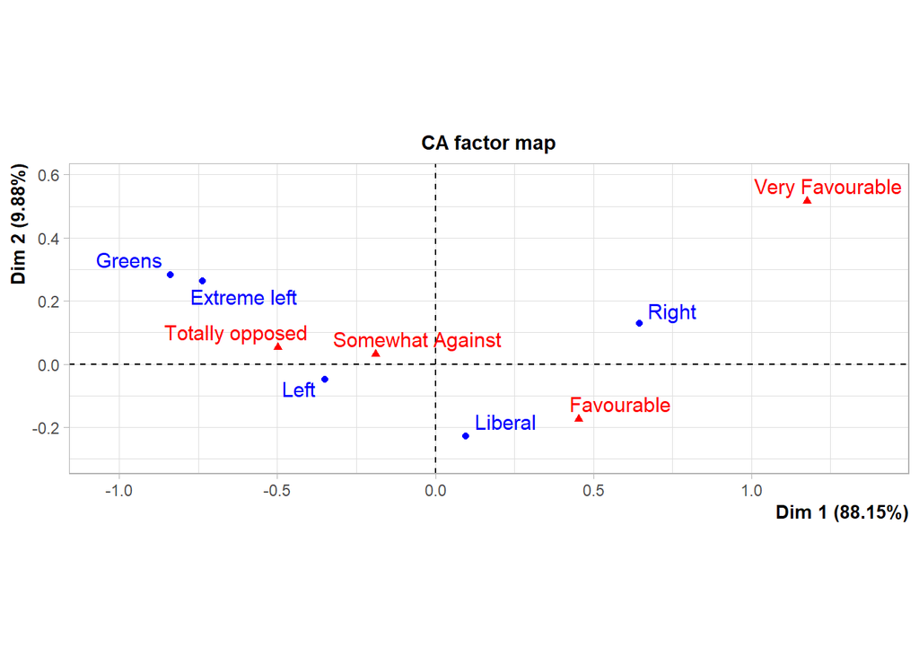

We can observe a Guttman effect, with a *parabolic* form.

You can also only represent variables or individuals :

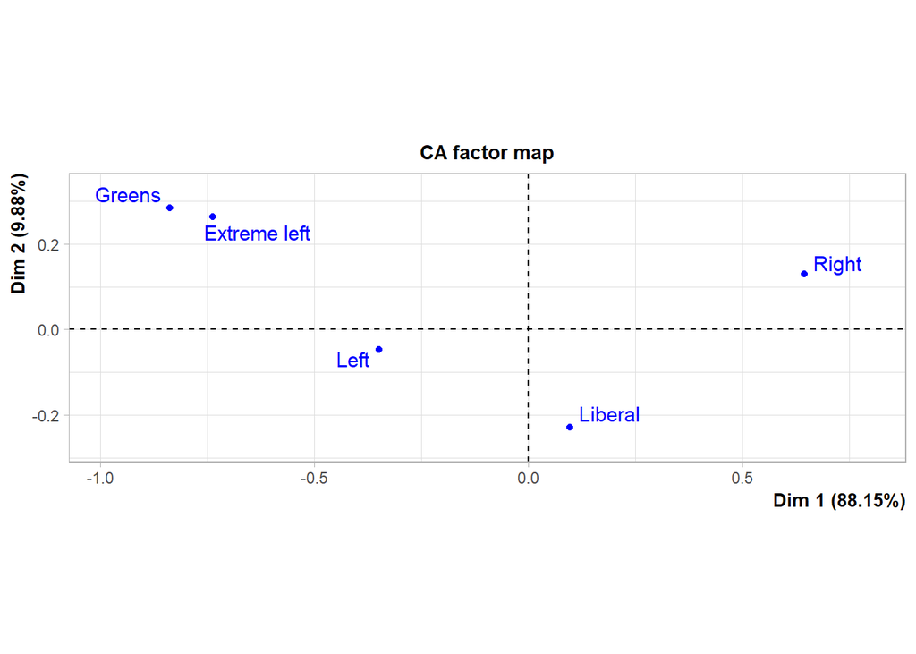

```r
plot(res.CA, invisible = "col")
```

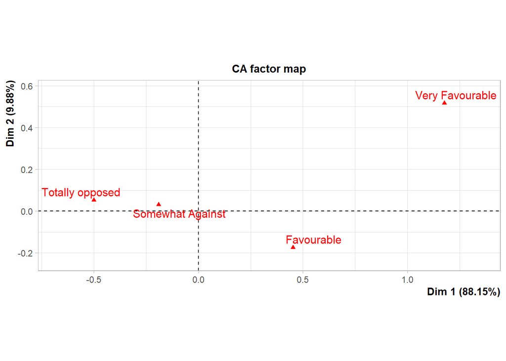

```r
plot(res.CA, invisible = "row")
```

#Categories involvement in independance

`descfreq` describes the rows or groups of rows in a contingency table

```r
res.descfreq <- descfreq(GMO_table, proba = 1)
res.descfreq
```

```
## $`Extreme left`
##                  Intern %    glob % Intern freq Glob freq     p.value
## Totally.opposed  55.55556 32.592593           5         44 0.25172759
## Somewhat.Against 44.44444 28.888889           4         39 0.47880864
## Very.Favourable   0.00000  5.925926           0          8 0.86594977
## Favourable        0.00000 32.592593           0         44 0.05015317
##                      v.test
## Totally.opposed   1.1461633
## Somewhat.Against  0.7082200
## Very.Favourable  -0.1688053
## Favourable       -1.9586553
##
## $Greens
##                  Intern %    glob % Intern freq Glob freq     p.value
## Totally.opposed  71.42857 32.592593           5         44 0.07408518
## Very.Favourable   0.00000  5.925926           0          8 0.70902517
## Somewhat.Against 28.57143 28.888889           2         39 0.65108223
## Favourable        0.00000 32.592593           0         44 0.11693774
##                      v.test
## Totally.opposed   1.7860870
## Very.Favourable  -0.3731656
## Somewhat.Against -0.4522592
## Favourable       -1.5677575
##
## $Left
##                  Intern %    glob % Intern freq Glob freq     p.value
## Totally.opposed  42.55319 32.592593          20         44 0.10870105
## Somewhat.Against 34.04255 28.888889          16         39 0.44166739
## Favourable       23.40426 32.592593          11         44 0.13828272
## Very.Favourable   0.00000  5.925926           0          8 0.05803996
##                      v.test
## Totally.opposed   1.6040590
## Somewhat.Against  0.7693806
## Favourable       -1.4822164
## Very.Favourable  -1.8953960
##
## $Liberal
##                  Intern %    glob % Intern freq Glob freq    p.value     v.test
## Favourable         43.750 32.592593          14         44 0.1874638  1.3181191
## Very.Favourable     3.125  5.925926           1          8 0.7872016 -0.2699463
## Somewhat.Against   25.000 28.888889           8         39 0.7515559 -0.3165884
## Totally.opposed    28.125 32.592593           9         44 0.6970442 -0.3893136
##
## $Right
##                  Intern %    glob % Intern freq Glob freq      p.value
## Very.Favourable      17.5  5.925926           7          8 0.001668722
## Favourable           47.5 32.592593          19         44 0.029800174
## Somewhat.Against     22.5 28.888889           9         39 0.394774530
## Totally.opposed      12.5 32.592593           5         44 0.001534744
##                      v.test
## Very.Favourable   3.1436195
## Favourable        2.1727363
## Somewhat.Against -0.8509907
## Totally.opposed  -3.1680324
##
## attr(,"class")
## [1] "descfreq" "list"
```

The V-test is used to transform p-values into scores that are more easily interpretable. The main feature of this indicator is that it can be positive, or negative, depending on the test that has been performed. It is closed to a Z-score.

# Pratic example with barbes

```r
library(readxl)
library(dplyr)
library(FactoMineR)
library(vietnameseConverter)
library(stringi)
```

## Import + modifications

```r
barbesV2 <- read_excel("data/barbesV2.xlsx")
barbesV2 <- barbesV2 %>% mutate(trad_sans_accents = stri_trans_general(Trad, "Latin-ASCII"))
barbesV2$Juge <- as.factor(barbesV2$Juge)
barbesV2$Barbes <- as.factor(barbesV2$Barbes)

barbesV2.viet.acc <- as.data.frame(barbesV2[, -c(3,5)])
barbesV2.viet.sans.acc <- as.data.frame(barbesV2[, -c(3,4)])
barbesV2.en <- as.data.frame(barbesV2[,-c(4,5)])
```

### Anglais :

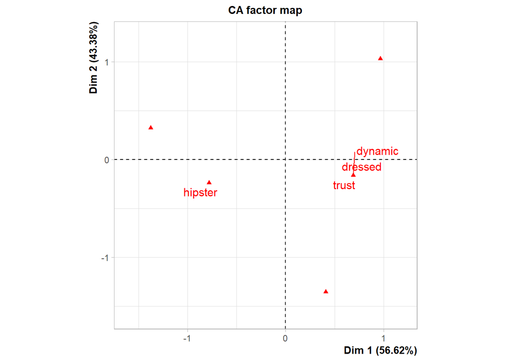

```r
res.textual.en.V2 <- textual(barbesV2.en,num.text = 3, contingence.by = 2, sep.word = ";")

eff.en.V2 <- as.data.frame(apply(res.textual.en.V2$cont.table, MARGIN = 2, FUN=sum))

words_selection.en.V2 <- res.textual.en.V2$cont.table[,apply(res.textual.en.V2$cont.table, 2, sum)>=1]
res.CA.en.V2 <- CA(words_selection.en.V2, graph=FALSE)

plot.CA(res.CA.en.V2, invisible = "row")
```

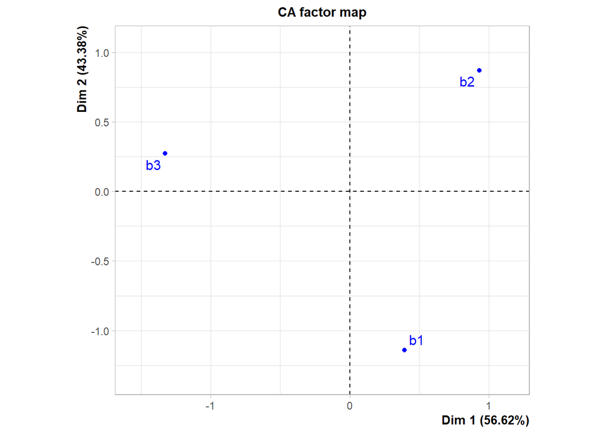

```r
plot.CA(res.CA.en.V2, invisible="col")
```

### Vietnamien avec accents :

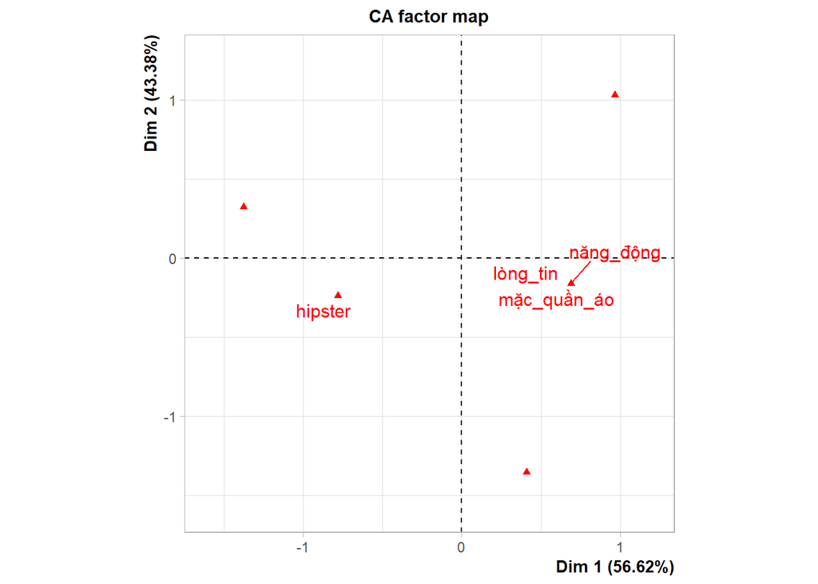

```r
res.textual.viet.V2 <- textual(barbesV2.viet.acc,num.text = 3, contingence.by = 2, sep.word = ";")

eff.viet.V2 <- as.data.frame(apply(res.textual.viet.V2$cont.table, MARGIN = 2, FUN=sum))

words_selection.viet.V2 <- res.textual.viet.V2$cont.table[,apply(res.textual.viet.V2$cont.table, 2, sum)>=1]

res.CA.viet.V2 <- CA(words_selection.viet.V2, graph=FALSE)
plot.CA(res.CA.viet.V2, invisible="row")
```

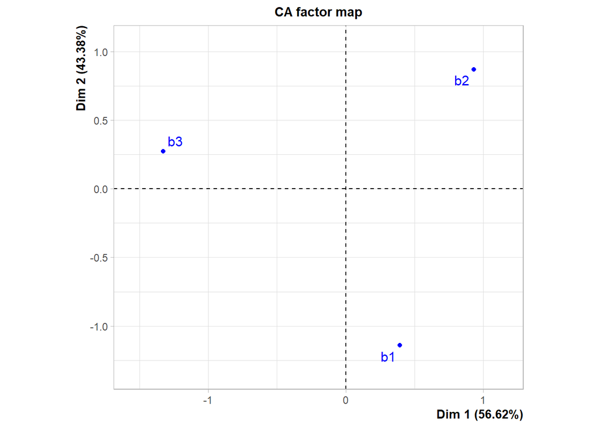

```r
plot.CA(res.CA.viet.V2, invisible="col")
```

### Vietnamien sans accents :

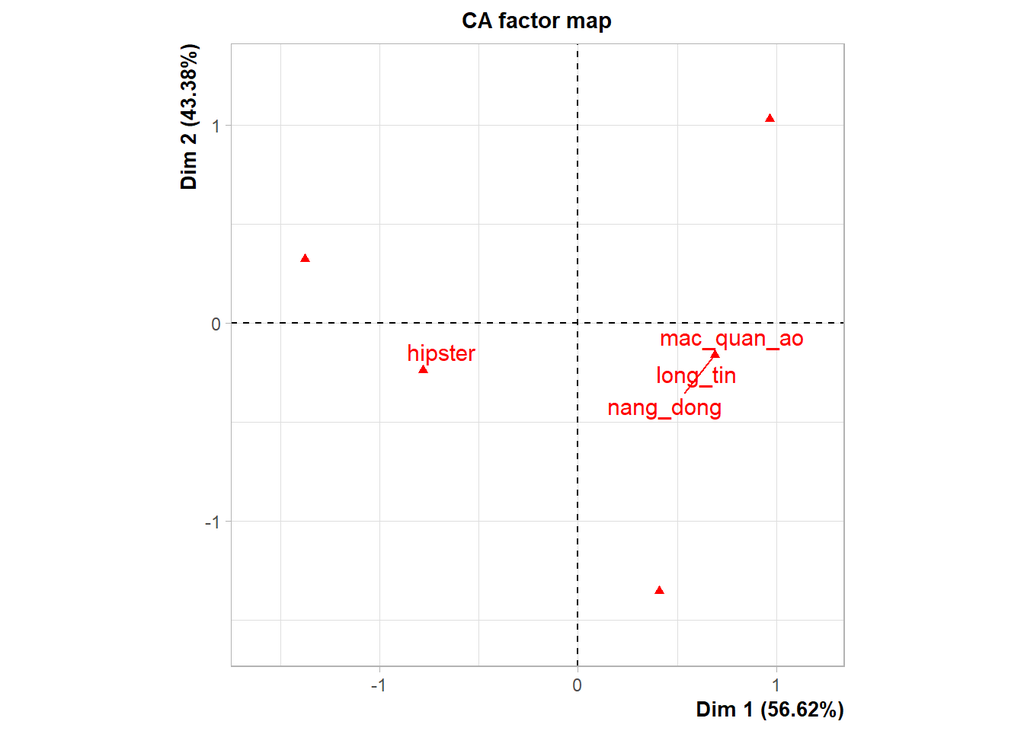

```r
res.textual.viet.sans.accent.V2 <- textual(barbesV2.viet.sans.acc,num.text = 3, contingence.by = 2, sep.word = ";")

eff.viet.V2 <- as.data.frame(apply(res.textual.viet.sans.accent.V2$cont.table, MARGIN = 2, FUN=sum))

words_selection.viet.sans.accent.V2 <- res.textual.viet.sans.accent.V2$cont.table[,apply(res.textual.viet.sans.accent.V2$cont.table, 2, sum)>=1]

res.CA.viet.sans.accent.V2 <- CA(words_selection.viet.sans.accent.V2, graph=FALSE)
plot.CA(res.CA.viet.sans.accent.V2, invisible = "row")
```

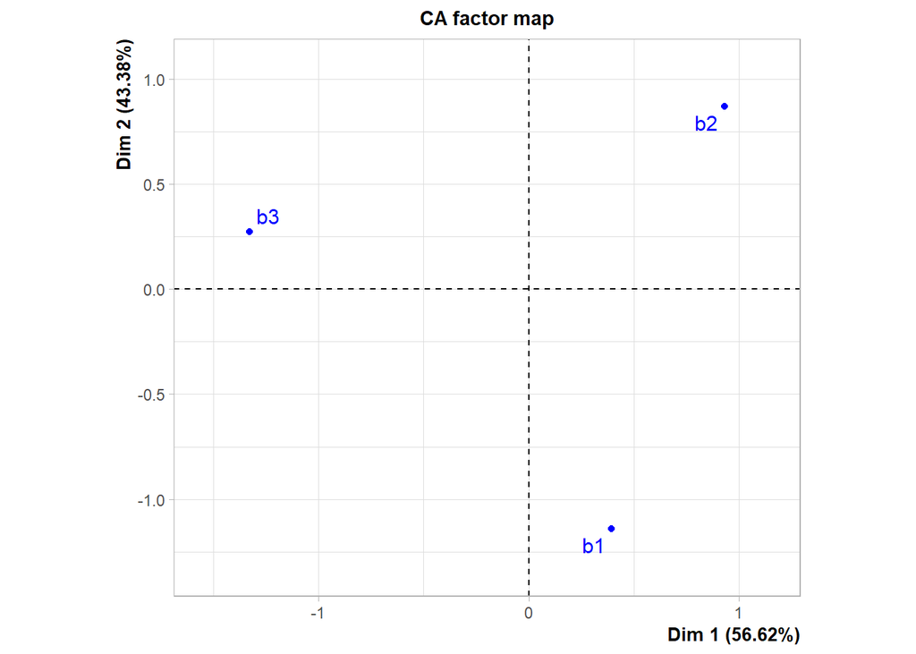

```r
plot.CA(res.CA.viet.sans.accent.V2, invisible = "col")
```

### Comparaison

```r
coord.en.V2 <- data.frame("words"=rownames(res.CA.en.V2$col$coord))
coord.en.V2 <- coord.en.V2 %>% mutate(Dim1.en=res.CA.en.V2$col$coord[,1], Dim2.en=res.CA.en.V2$col$coord[,2])
coord.en.V2 <- as.data.frame(coord.en.V2[order(coord.en.V2$Dim1.en,coord.en.V2$Dim2.en),])

coord.viet.acc.V2 <- data.frame("words"=rownames(res.CA.viet.V2$col$coord))
coord.viet.acc.V2 <- coord.viet.acc.V2 %>% mutate(Dim1.viet.acc = res.CA.viet.V2$col$coord[,1], Dim2.viet.acc=res.CA.viet.V2$col$coord[,2])
coord.viet.acc.V2 <- as.data.frame(coord.viet.acc.V2[order(coord.viet.acc.V2$Dim1.viet.acc,coord.viet.acc.V2$Dim2.viet.acc),])

coord.viet.sans.acc.V2 <- data.frame("words"=rownames(res.CA.viet.sans.accent.V2$col$coord))
coord.viet.sans.acc.V2 <- coord.viet.sans.acc.V2 %>% mutate(Dim1.viet.sans.acc = res.CA.viet.sans.accent.V2$col$coord[,1], Dim2.viet.sans.acc=res.CA.viet.sans.accent.V2$col$coord[,2])
coord.viet.sans.acc.V2 <- as.data.frame(coord.viet.sans.acc.V2[order(coord.viet.sans.acc.V2$Dim1.viet.sans.acc,coord.viet.sans.acc.V2$Dim2.viet.sans.acc),])

coord <- cbind(coord.en.V2, coord.viet.acc.V2, coord.viet.sans.acc.V2)
```

Conclusion : - pas de différence entre CA mots anglais versus mots vietnamiens (warnings sur l’encodage lors de la CA mais coordonnées pareilles); - aucune utilité des mots vietnamiens sans accents